# Testowanie…

1 marca 2017

## Wybór testu

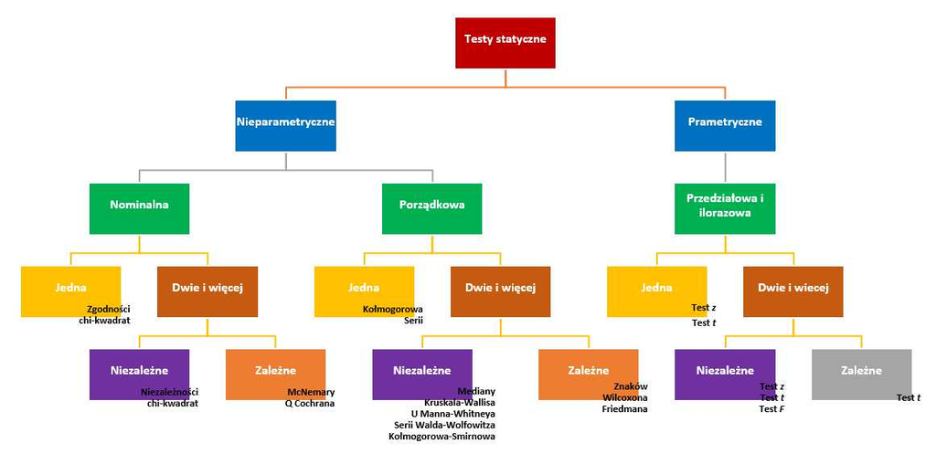

## Generowanie rozkładów liczb

rozkład dwumianowy

```r
?rbinom
```

```r
?rnorm
```

## Generowanie rozkładów liczb - rozkład dwumianowy

```r
(b1 <- rbinom(20, 1, 1))
```

```
##  [1] 1 1 1 1 1 1 1 1 1 1 1 1 1 1 1 1 1 1 1 1
```

```r
(b2 <- rbinom(20, 1, .9))
```

```
##  [1] 1 1 1 1 1 1 1 1 1 1 1 1 1 0 1 1 1 1 1 1
```

```r
(b3 <- rbinom(20, 1, .5))
```

```
##  [1] 1 1 1 0 0 1 1 1 1 1 0 1 0 1 1 0 1 0 1 1
```

```r
(b4 <- rbinom(20, 1, .1))
```

```
##  [1] 0 0 0 0 0 0 0 1 0 0 0 0 0 0 1 0 0 0 0 0
```

## Generowanie rozkładów liczb - rozkład normalny

```r
(n1 <- rnorm(10))
```

```
##  [1]  0.05333212 -0.90967059 -1.65187425  0.61184418  0.04908683
##  [6] -1.41957830  1.94254006 -0.08863088  0.53163050  0.75008339
```

```r
(n2 <- rnorm(20))
```

```
##  [1] -0.74473433  0.47684386 -1.76774973 -1.10195050  0.12000043
##  [6] -0.20613468  0.80761650 -0.67268741 -1.23879540  0.47072766
## [11]  1.46979500  0.93878383  0.41286721  0.40156057  1.15137247
## [16]  0.70079463  0.65501205 -0.55203613  0.07259457  0.91549510
```

```r
(n3 <- rnorm(10, 50, 1))
```

```
##  [1] 48.68744 49.44111 50.56024 50.21774 50.99839 50.08725 50.91072
##  [8] 50.68158 50.17929 49.75241
```

```r
n4 <- rnorm(1000, 50, 10)
```

## Generowanie rozkładów liczb - rozkład normalny

```r
summary(n1)
```

```
##     Min.  1st Qu.   Median     Mean  3rd Qu.     Max.
## -1.65200 -0.70440  0.05121 -0.01312  0.59180  1.94300
```

```r
#summary(n2)
summary(n3)
```

```
##    Min. 1st Qu.  Median    Mean 3rd Qu.    Max.
##   48.69   49.84   50.20   50.15   50.65   51.00
```

```r
summary(n4)
```

```
##    Min. 1st Qu.  Median    Mean 3rd Qu.    Max.
##   22.36   44.38   50.40   50.48   57.13   78.81
```

## Generowanie rozkładów liczb - rozkład normalny

```r
help1 <- rbind(data.frame(val=n1, set=1), data.frame(val=n2, set=2),
               data.frame(val=n3, set=3), data.frame(val=n4, set=4))
head(help1)
```

```
##           val set
## 1  0.05333212   1
## 2 -0.90967059   1
## 3 -1.65187425   1
## 4  0.61184418   1
## 5  0.04908683   1
## 6 -1.41957830   1
```

```r
tail(help1)
```

```
##           val set
## 1035 55.10170   4
## 1036 40.70730   4
## 1037 51.18142   4
## 1038 56.95657   4
## 1039 36.88701   4
## 1040 67.46279   4
```

## Generowanie rozkładów liczb - rozkład normalny

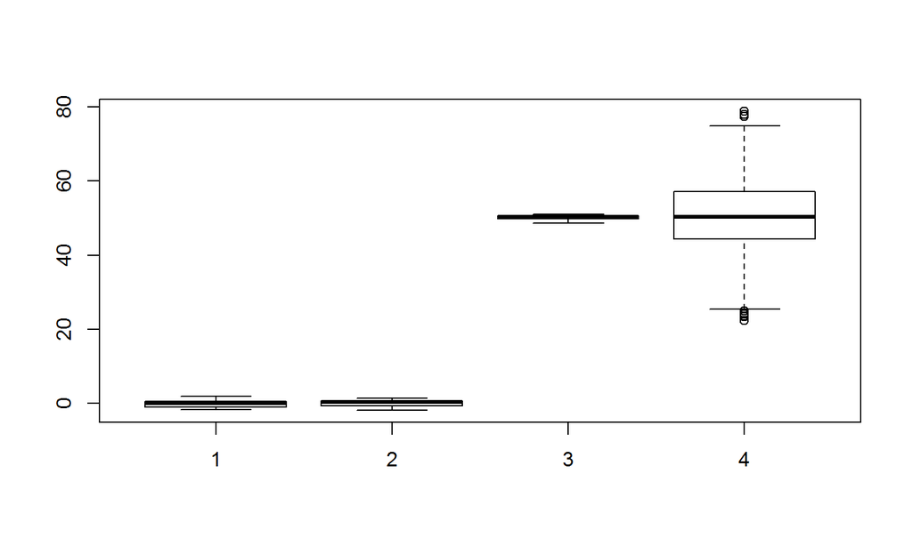

```r
boxplot(help1$val~help1$set)
```

## 1. Test Shapiro-Wilka

- zastosowanie: testowanie zgodności z rozkładem normalnym (→ analiza wariancji, regresja liniowa),
- hipoteza zerowa: dane pochodzą z rozkładu normalnego (np. zmienna Y w analizie wariancji, reszty modelu regresji)
- wielkość próby: od 3 do 5000 obserwacji

## 1. Test Shapiro-Wilka

```r
dat <- rnorm(500)
shapiro.test(dat)
```

```
##
##  Shapiro-Wilk normality test
##
## data:  dat
## W = 0.99728, p-value = 0.5838
```

## 1. Test Shapiro-Wilka

```r
dat <- runif(100000)
#shapiro.test(dat)
#Error in shapiro.test(dat_log) : sample size must be between 3 and 5000
#shapiro.test(dat_log)

shapiro.test(sample(dat, 500))
```

```
##
##  Shapiro-Wilk normality test
##
## data:  sample(dat, 500)
## W = 0.94976, p-value = 5.369e-12
```

## 2. Test Kołmogorowa-Smirnowa

- zastosowanie: testowanie zgodności rozkładów dwóch prób,
- hipoteza zerowa: rozkład próby X jest taki sam, jak rozkład próby Y
- https://www.rdocumentation.org/packages/stats/versions/3.3.2/topics/ks.test

## 2. Test Kołmogorowa-Smirnowa

```r
x <- rnorm(100)
y <- rnorm(100)
z <- runif(100)

tail(x)
```

```
## [1] -0.3408786 -0.7496886  0.8882659  0.4596729 -2.5468926  1.2018478
```

```r
head(y)
```

```
## [1]  0.42412857 -3.12510001 -0.03553177  0.22958377  0.21922855  2.03152916
```

```r
z[1:20]
```

```
##  [1] 0.42226935 0.13669256 0.14802249 0.71050595 0.30014199 0.93221053
##  [7] 0.55991271 0.05414861 0.98864362 0.58396212 0.89858848 0.03873558
## [13] 0.24493632 0.73580467 0.02271576 0.08432016 0.46270847 0.11330942
## [19] 0.90028271 0.18179493
```

## 2. Test Kołmogorowa-Smirnowa

```r
ks.test(x, y)
```

```
##
##  Two-sample Kolmogorov-Smirnov test
##
## data:  x and y
## D = 0.14, p-value = 0.281
## alternative hypothesis: two-sided
```

```r
ks.test(x, z)
```

```
##
##  Two-sample Kolmogorov-Smirnov test
##
## data:  x and z
## D = 0.53, p-value = 1.264e-12
## alternative hypothesis: two-sided
```

## 3. Test t studenta dla jednej próby

- zastosowanie: testowanie równości średniej z próby z określoną wartością
- hipoteza zerowa: H0: μ = μ0
- założenie: próba pochodzi z rozkładu normalnego
- t.test(x, mu=liczba)
- https://www.datacamp.com/courses/intro-to-statistics-with-r-student-s-t-test

## 3. Test t studenta dla jednej próby

```r
x <- rnorm(1000)
t.test(x, mu=0)
```

```
##
##  One Sample t-test
##
## data:  x
## t = 0.69111, df = 999, p-value = 0.4897
## alternative hypothesis: true mean is not equal to 0
## 95 percent confidence interval:
##  -0.03964839  0.08275814
## sample estimates:
##  mean of x
## 0.02155487
```

## 3. Test t studenta dla jednej próby

```r
z <- rnorm(1000, 10, 1)
t.test(z, mu=0)
```

```
##
##  One Sample t-test
##
## data:  z
## t = 312.83, df = 999, p-value < 2.2e-16
## alternative hypothesis: true mean is not equal to 0
## 95 percent confidence interval:
##   9.998247 10.124473
## sample estimates:
## mean of x
##  10.06136
```

## 4. Test t studenta dla dwóch prób niezależnych

- zastosowanie: testowanie równości średnich dwóch niepowiązanych prób
- hipoteza zerowa: H0: μ1 = μ2
- założenia: próby pochodzą z rozkładu normalnego
- t.test(x, y)

## 4. Test t studenta dla dwóch prób niezależnych

```r
x <- rnorm(1000, 10, 5)
y <- rnorm(800, 10, 10)
z <- rnorm(900, 15, 8)

summary(x)
```

```
##    Min. 1st Qu.  Median    Mean 3rd Qu.    Max.
##  -5.511   6.259   9.925   9.875  13.300  24.580
```

```r
summary(y)
```

```
##    Min. 1st Qu.  Median    Mean 3rd Qu.    Max.
## -19.810   2.641   9.651   9.505  16.270  42.470
```

```r
summary(z)
```

```
##    Min. 1st Qu.  Median    Mean 3rd Qu.    Max.
## -10.900   9.655  14.980  15.050  19.920  37.660
```

## 4. Test t studenta dla dwóch prób niezależnych

```r
t.test(x, y)
```

```
##
##  Welch Two Sample t-test
##
## data:  x and y
## t = 0.95159, df = 1109.4, p-value = 0.3415
## alternative hypothesis: true difference in means is not equal to 0
## 95 percent confidence interval:
##  -0.3936007  1.1348957
## sample estimates:
## mean of x mean of y
##  9.875350  9.504703
```

## 4. Test t studenta dla dwóch prób niezależnych

```r
t.test(x, z)
```

```
##
##  Welch Two Sample t-test
##
## data:  x and z
## t = -17.129, df = 1508.4, p-value < 2.2e-16
## alternative hypothesis: true difference in means is not equal to 0
## 95 percent confidence interval:
##  -5.769850 -4.584151
## sample estimates:
## mean of x mean of y
##   9.87535  15.05235
```

## 5. Test t studenta dla dwóch prób zależnych

- zastosowanie: testowanie równości średnich dwóch powiązanych prób
- hipoteza zerowa: H0: µ1 = µ2
- założenia: próby pochodzą z rozkładu normalnego
- próby są równoliczne
- t.test(x, y, paired = T)

## 5. Test t studenta dla dwóch prób zależnych

```r
x <- rnorm(1000, 10, 5)
y <- rnorm(1000, 10, 1)
z <- rnorm(1000, 15, 5)

summary(x)
```

```
##    Min. 1st Qu.  Median    Mean 3rd Qu.    Max.
##  -6.690   6.587  10.010  10.070  13.490  26.420
```

```r
summary(y)
```

```
##    Min. 1st Qu.  Median    Mean 3rd Qu.    Max.
##   6.581   9.343   9.996   9.996  10.700  13.160
```

```r
summary(z)
```

```
##    Min. 1st Qu.  Median    Mean 3rd Qu.    Max.
##  -1.828  11.440  14.890  14.830  18.180  31.450
```

## 5. Test t studenta dla dwóch prób zależnych

```r
t.test(x, y, paired=T)
```

```
##
##  Paired t-test
##
## data:  x and y
## t = 0.4588, df = 999, p-value = 0.6465
## alternative hypothesis: true difference in means is not equal to 0
## 95 percent confidence interval:
##  -0.2524579  0.4065297
## sample estimates:
## mean of the differences
##              0.07703588
```

## 5. Test t studenta dla dwóch prób zależnych

```r
t.test(x, z, paired=T)
```

```
##
##  Paired t-test
##
## data:  x and z
## t = -20.619, df = 999, p-value < 2.2e-16
## alternative hypothesis: true difference in means is not equal to 0
## 95 percent confidence interval:
##  -5.215347 -4.308917
## sample estimates:
## mean of the differences
##               -4.762132
```

## 6. Test Wilcoxona dla par obserwacji

- zastosowanie: testowanie równości średnich jednej lub dwóch prób
- hipoteza zerowa: H0: µ = µ0 lub H0: µ1 = µ2
- uwaga: brak założeń dotyczących rozkładu prób
- wilcox.test(x, mu=liczba)
- wilcox.test(x, y)
- wilcox.test(x, y, paired=T)
- https://campus.datacamp.com/courses/r-for-sas-spss-and-stata-users-r-tutorial/chapter-18-comparing-groups?ex=14

## 6. Test Wilcoxona dla par obserwacji

```r
x <- runif(100)
y <- rnorm(100)

wilcox.test(x, mu=0)
```

```
##
##  Wilcoxon signed rank test with continuity correction
##
## data:  x
## V = 5050, p-value < 2.2e-16
## alternative hypothesis: true location is not equal to 0
```

```r
wilcox.test(y, mu=0)
```

```
##
##  Wilcoxon signed rank test with continuity correction
##
## data:  y
## V = 2204, p-value = 0.2705
## alternative hypothesis: true location is not equal to 0
```

## 6. Test Wilcoxona dla par obserwacji

```r
wilcox.test(x, y)
```

```
##
##  Wilcoxon rank sum test with continuity correction
##
## data:  x and y
## W = 7288, p-value = 2.28e-08
## alternative hypothesis: true location shift is not equal to 0
```

```r
wilcox.test(x, y, paired=T)
```

```
##
##  Wilcoxon signed rank test with continuity correction
##
## data:  x and y
## V = 3903, p-value = 2.177e-06
## alternative hypothesis: true location shift is not equal to 0
```

## 7. Test Kruskala-Wallisa

- zastosowanie: testowanie równości średnich wielu prób
- uogólnienie testu Wilcoxona
- kruskal.test(list(próba1, próba2, próba3, …))

## 7. Test Kruskala-Wallisa

```r
w <- runif(200, 1, 2)
x <- runif(200)
y <- runif(200)
z <- rnorm(200, .5, 1)

summary(w)
```

```
##    Min. 1st Qu.  Median    Mean 3rd Qu.    Max.
##   1.019   1.265   1.535   1.510   1.751   1.998
```

```r
summary(x)
```

```
##     Min.  1st Qu.   Median     Mean  3rd Qu.     Max.
## 0.001746 0.251600 0.506300 0.492700 0.741100 0.994900
```

```r
#summary(y)
summary(z)
```

```
##    Min. 1st Qu.  Median    Mean 3rd Qu.    Max.
## -2.4520 -0.1393  0.4791  0.4960  1.2470  3.4100
```

## 7. Test Kruskala-Wallisa

```r
kruskal.test(list(x, y, z))
```

```
##
##  Kruskal-Wallis rank sum test
##
## data:  list(x, y, z)
## Kruskal-Wallis chi-squared = 0.27757, df = 2, p-value = 0.8704
```

```r
kruskal.test(list(w, x, y, z))
```

```
##
##  Kruskal-Wallis rank sum test
##
## data:  list(w, x, y, z)
## Kruskal-Wallis chi-squared = 347.7, df = 3, p-value < 2.2e-16
```

## 8. Test F

- zastosowanie: testowanie jednorodności wariancji dwóch prób
- hipoteza zerowa: H0: var1 = var2
- var.test(próba1, próba2)

## 8. Test F

```r
x <- runif(200)
y <- runif(200)
z <- rnorm(200, .5, 1)

summary(x)
```

```
##     Min.  1st Qu.   Median     Mean  3rd Qu.     Max.
## 0.001153 0.281500 0.539600 0.527500 0.762800 0.999500
```

```r
summary(y)
```

```
##     Min.  1st Qu.   Median     Mean  3rd Qu.     Max.
## 0.002796 0.262600 0.533100 0.518000 0.778900 0.999100
```

```r
summary(z)
```

```
##    Min. 1st Qu.  Median    Mean 3rd Qu.    Max.
## -2.3120 -0.1979  0.3537  0.4171  1.0920  3.4330
```

## 8. Test F

```r
var.test(x, y)
```

```
##
##  F test to compare two variances
##
## data:  x and y
## F = 1.0359, num df = 199, denom df = 199, p-value = 0.804
## alternative hypothesis: true ratio of variances is not equal to 1
## 95 percent confidence interval:
##  0.7839267 1.3687641
## sample estimates:
## ratio of variances
##           1.035862
```

## 8. Test F

```r
var.test(x, z)
```

```
##
##  F test to compare two variances
##
## data:  x and z
## F = 0.095977, num df = 199, denom df = 199, p-value < 2.2e-16
## alternative hypothesis: true ratio of variances is not equal to 1
## 95 percent confidence interval:
##  0.07263438 0.12682223
## sample estimates:
## ratio of variances
##         0.09597736
```

## 9. Test Ansari-Bradley

- zastosowanie: testowanie jednorodności wariancji dwóch prób
- hipoteza zerowa: H0: var1 = var2
- ansari.test(próba1, próba2)

## 9. Test Ansari-Bradley

```r
x <- runif(200)
y <- runif(200)
z <- rnorm(200, .5, 1)

summary(x)
```

```
##     Min.  1st Qu.   Median     Mean  3rd Qu.     Max.
## 0.001628 0.221300 0.506200 0.490700 0.744600 0.995100
```

```r
summary(y)
```

```
##     Min.  1st Qu.   Median     Mean  3rd Qu.     Max.
## 0.001532 0.258400 0.519300 0.502300 0.744000 0.995800
```

```r
summary(z)
```

```
##     Min.  1st Qu.   Median     Mean  3rd Qu.     Max.
## -2.01500 -0.08284  0.50500  0.48430  0.96700  2.78200
```

## 9. Test Ansari-Bradley

```r
ansari.test(x, y)
```

```
##
##  Ansari-Bradley test
##
## data:  x and y
## AB = 19908, p-value = 0.7398
## alternative hypothesis: true ratio of scales is not equal to 1
```

## 9. Test Ansari-Bradley

```r
ansari.test(x, z)
```

```
##
##  Ansari-Bradley test
##
## data:  x and z
## AB = 24775, p-value = 6.661e-16
## alternative hypothesis: true ratio of scales is not equal to 1
```

## 10. Test Bartletta

- zastosowanie: testowanie jednorodności wariancji wielu prób
- hipoteza zerowa: H0: var1 = var2 = var3 = ..
- bartlett.test(list(x, y, …))
- bartlett.test(x, g=czynnik dzielący dane)

## 10. Test Bartletta

```r
x <- runif(200)
y <- runif(200)
z <- rnorm(200, .5, 1)

bartlett.test(list(x, y, z))
```

```
##
##  Bartlett test of homogeneity of variances
##
## data:  list(x, y, z)
## Bartlett's K-squared = 403.02, df = 2, p-value < 2.2e-16
```

## 11. Test prawdopodobieństwa sukcesu

- zastosowanie: testowanie możliwości wystąpienia określonej liczby sukcesów w zadanej liczbie prób przy wskazanym prawdopodobieństwie
- prop.test(liczba sukcesów, liczba prób, prawdopodobieństwo)

```r
prop.test(50, 100, .5)
```

```
##
##  1-sample proportions test without continuity correction
##
## data:  50 out of 100, null probability 0.5
## X-squared = 0, df = 1, p-value = 1
## alternative hypothesis: true p is not equal to 0.5
## 95 percent confidence interval:
##  0.4038315 0.5961685
## sample estimates:
##   p
## 0.5
```

## 11. Test prawdopodobieństwa sukcesu

```r
prop.test(50, 100, .25)
```

```
##
##  1-sample proportions test with continuity correction
##
## data:  50 out of 100, null probability 0.25
## X-squared = 32.013, df = 1, p-value = 1.531e-08
## alternative hypothesis: true p is not equal to 0.25
## 95 percent confidence interval:
##  0.3990211 0.6009789
## sample estimates:
##   p
## 0.5
```

## 12. Test chi2 na niezależność

- zastosowanie: testowanie równości częstości występowania poszczególnych cech w populacji
- hipoteza zerowa: poszczególne cechy w populacji występują niezależnie od siebie, z równą częstością
- chisq.test(table(zbiór danych))

## 12. Test chi2 na niezależność

```r
## From Agresti(2007) p.39
M <- as.table(rbind(c(762, 327, 468), c(484, 239, 477)))
dimnames(M) <- list(gender = c("F", "M"),
                    party = c("Democrat","Independent", "Republican"))
M
```

```
##       party
## gender Democrat Independent Republican
##      F      762         327        468
##      M      484         239        477
```

```r
chisq.test(M)
```

```
##
##  Pearson's Chi-squared test
##
## data:  M
## X-squared = 30.07, df = 2, p-value = 2.954e-07
```

## 12. Test chi2 na niezależność

```r
lek=c(19,41,60)
ctl=c(46,19,15)
chisq.test(cbind(lek,ctl))
```

```
##
##  Pearson's Chi-squared test
##
## data:  cbind(lek, ctl)
## X-squared = 39.877, df = 2, p-value = 2.192e-09
```

## 13. Dokładny test Fishera

- odpowiednik testu chi2 dla małych liczebności w komórkach tablicy kontyngencji są niewielkie (< 10)
- test chi2 oraz test Fishera „zastępują analizę wariancji” dla zmiennych skokowych

## 13. Dokładny test Fishera

```r
## From Agresti (1990, p. 61f; 2002, p. 91)
TeaTasting <- matrix(c(3, 1, 1, 3),
              nrow = 2,
              dimnames = list(Guess = c("Milk", "Tea"),
                              Truth = c("Milk", "Tea")))
TeaTasting
```

```
##       Truth
## Guess  Milk Tea
##   Milk    3   1
##   Tea     1   3
```

```r
fisher.test(TeaTasting)
```

```
##
##  Fisher's Exact Test for Count Data
##
## data:  TeaTasting
## p-value = 0.4857
## alternative hypothesis: true odds ratio is not equal to 1
## 95 percent confidence interval:
##    0.2117329 621.9337505
## sample estimates:
## odds ratio
##   6.408309
```

## agricolae: Statistical Procedures for Agricultural Research

- The Least Significant Difference (LSD)
- korekty na wielokrotne testowanie?
- Duncan’s New Multiple-Range Test
- Tukey’s W Procedure (HSD)
- Kruskal-Wallis: adjust P-values
- Median test

## 14. Test Duncan’a

```r
#install.packages("agricolae")
library(agricolae)
data(sweetpotato)
sweetpotato
```

```
##    virus yield
## 1     cc  28.5
## 2     cc  21.7
## 3     cc  23.0
## 4     fc  14.9
## 5     fc  10.6
## 6     fc  13.1
## 7     ff  41.8
## 8     ff  39.2
## 9     ff  28.0
## 10    oo  38.2
## 11    oo  40.4
## 12    oo  32.1
```

## 14. Test Duncan’a

```r
model <- aov(yield~virus, data=sweetpotato)
model
```

```
## Call:
##    aov(formula = yield ~ virus, data = sweetpotato)
##
## Terms:
##                     virus Residuals
## Sum of Squares  1170.2092  179.9133
## Deg. of Freedom         3         8
##
## Residual standard error: 4.742274
## Estimated effects may be unbalanced
```

```r
summary(model)
```

```
##             Df Sum Sq Mean Sq F value   Pr(>F)
## virus        3 1170.2   390.1   17.34 0.000733 ***
## Residuals    8  179.9    22.5
## ---
## Signif. codes:  0 '***' 0.001 '**' 0.01 '*' 0.05 '.' 0.1 ' ' 1
```

```r
duncan.test(model, "virus",console=TRUE)
```

```
##
## Study: model ~ "virus"
##
## Duncan's new multiple range test
## for yield
##
## Mean Square Error:  22.48917
##
## virus,  means
##
##       yield      std r  Min  Max
## cc 24.40000 3.609709 3 21.7 28.5
## fc 12.86667 2.159475 3 10.6 14.9
## ff 36.33333 7.333030 3 28.0 41.8
## oo 36.90000 4.300000 3 32.1 40.4
##
## alpha: 0.05 ; Df Error: 8
##
## Critical Range
##        2        3        4
## 8.928965 9.304825 9.514910
##
## Means with the same letter are not significantly different.
##
## Groups, Treatments and means
## a     oo      36.9
## a     ff      36.33
## b     cc      24.4
## c     fc      12.87
```

## 14. Test Duncan’a

```r
(out <- duncan.test(model, "virus",console=TRUE))
```

```
##
## Study: model ~ "virus"
##
## Duncan's new multiple range test
## for yield
##
## Mean Square Error:  22.48917
##
## virus,  means
##
##       yield      std r  Min  Max
## cc 24.40000 3.609709 3 21.7 28.5
## fc 12.86667 2.159475 3 10.6 14.9
## ff 36.33333 7.333030 3 28.0 41.8
## oo 36.90000 4.300000 3 32.1 40.4
##
## alpha: 0.05 ; Df Error: 8
##
## Critical Range
##        2        3        4
## 8.928965 9.304825 9.514910
##
## Means with the same letter are not significantly different.
##
## Groups, Treatments and means
## a     oo      36.9
## a     ff      36.33
## b     cc      24.4
## c     fc      12.87
```

```
## $statistics
##     Mean      CV  MSerror
##   27.625 17.1666 22.48917
##
## $parameters
##   Df ntr alpha   test name.t
##    8   4  0.05 Duncan  virus
##
## $Duncan
##      Table CriticalRange
## 2 3.261182      8.928965
## 3 3.398460      9.304825
## 4 3.475191      9.514910
##
## $means
##       yield      std r  Min  Max
## cc 24.40000 3.609709 3 21.7 28.5
## fc 12.86667 2.159475 3 10.6 14.9
## ff 36.33333 7.333030 3 28.0 41.8
## oo 36.90000 4.300000 3 32.1 40.4
##
## $comparison
## NULL
##
## $groups
##   trt    means M
## 1  oo 36.90000 a
## 2  ff 36.33333 a
## 3  cc 24.40000 b
## 4  fc 12.86667 c
```

## 14. Test Duncan’a

```r
out$groups
```

```
##   trt    means M
## 1  oo 36.90000 a
## 2  ff 36.33333 a
## 3  cc 24.40000 b
## 4  fc 12.86667 c
```

## 14. Test Duncan’a

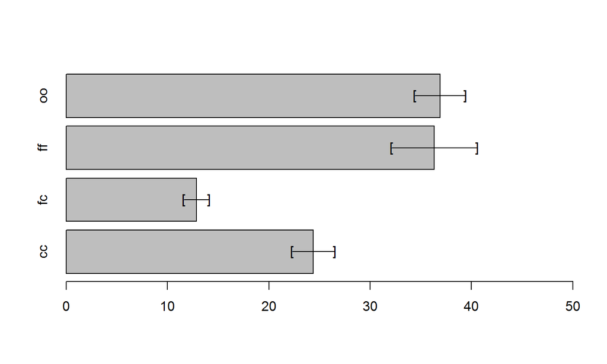

```r
bar.err(out$means, horiz=T, xlim=c(0, 50))
```

## Dziękuję za uwagę

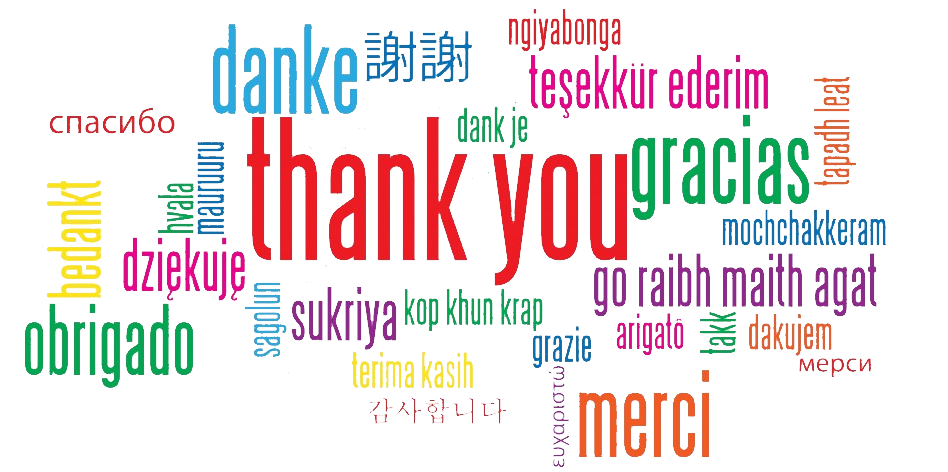

## Bonus!

https://www.rstudio.com/rviews/2017/02/22/how-to-teach-r-common-mistakes/